# MLM

## what about at the individual level?

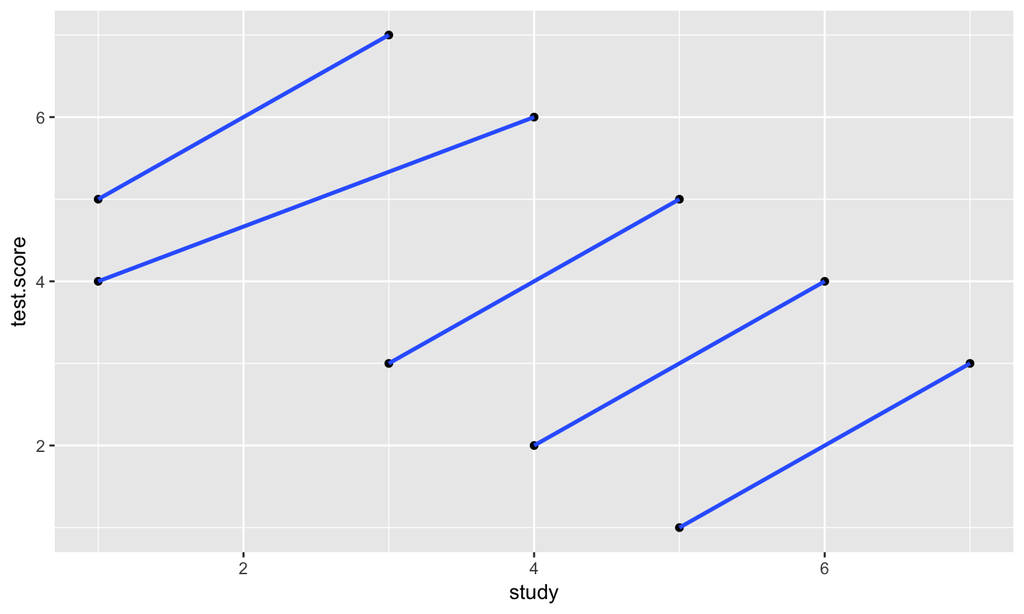

## Aggregating is bad

- Especially when it is easy to take into account
- Cons of aggregating:
  - reduced power
  - change the unit of analysis and thus change the meaning
  - more difficult to make inferences

## Examining the different levels is good

- Extracurricular activity (EA) and time spent studying
- Between person H1: Do students who participate in EA spend more time studying?
- Within person H2: When a student is participating in EA, do they spend more time studying (e.g., in-season vs. offseason)?
- Notice that H1 and H2 are independent from one another!

## fixed effects regression

\[ \hat{Y}_{i} = b_{0} + b_{1}X_{1} + b_{2}X_{2} + b_{3}X_{3}+...\] - parameters are considered fixed, only one value  
- can be thought of as purposefully selected or existing values of a variable; can only generalize to particular values used

## putting it together

Level 1: \[ {Y}_{ij} = \beta_{0j} +\varepsilon_{ij} \]

Level 2: \[ {\beta}_{0j} = \gamma_{00} + U_{0j}\]

Combined: \[ {Y}_{ij} = \gamma_{00} + U_{0j} + \varepsilon_{ij} \]

## Level 1 vs Level 2

- Level 1 is the smallest unit of analysis
  - students, observations, trials, family members
- Level 2 variables are constant for all level 1 variables that are “nested” in it
  - people, schools, counties, families, dyads
- Can have more than 2 levels

## Random intercepts, fixed slopes

Level 1: \[ {Y}_{ij} = \beta_{0j} + \beta_{1j}X_{1} + \varepsilon_{ij} \]

Level 2:  
\[ {\beta}_{0j} = \gamma_{00} + U_{0j}\]  
\[ {\beta}_{1j} = \gamma_{10} \]

Putting it together: \[ {Y}_{ij} = \gamma_{00} + \gamma_{10} (X_{1})+ U_{0j} + \varepsilon_{ij} \]

## What does this look like graphically?

- think of as an individual regressoin for each person
- because intercept are random, people can vary
- because slopes are fixed, people have the same slope
- two types of residuals:
  - represents how much variability there is in the intercepts from person to person
  - based on individual scores from their predicted score, much like around the regression line

## Random intercepts, random slopes

Level 1: \[ {Y}_{ij} = \beta_{0j} + \beta_{1j}(X_{1}) + \varepsilon_{ij} \]

Level 2:  
\[ {\beta}_{0j} = \gamma_{00} + U_{0j}\]  
\[ {\beta}_{1j} = \gamma_{10} + U_{1j} \]

Putting it together: \[ {Y}_{ij} = \gamma_{00} + \gamma_{10}(X_{1})+ U_{0j} + U_{1j} (X_{1})+ \varepsilon_{ij} \]

## adding covariates and predictors

- can add covariates and predictors at level 1 and level 2

## Estimation

- Maximum Likelihood
- Bayesian Estimation

## Data structure

- long vs wide
- use tidyr to convert

## Unconditional model

Level 1: \[ {Y}_{ij} = \beta_{0j} +\varepsilon_{ij} \]

Level 2: \[ {\beta}_{0j} = \gamma_{00} + U_{0j}\]

Combined: \[ {Y}_{ij} = \gamma_{00} + U_{0j} + \varepsilon_{ij} \]

ICC:

\[\frac{U_{0j}}{U_{0j}+ \varepsilon_{ij}}\]

- % variation between vs within group (person) variance

## Example

```r
alcohol1
```

```
## # A tibble: 246 x 9
##       id   age   coa  male age_14 alcuse  peer  cpeer  ccoa
##    <int> <int> <int> <int>  <int>  <dbl> <dbl>  <dbl> <dbl>
##  1     1    14     1     0      0   1.73 1.26   0.247 0.549
##  2     1    15     1     0      1   2.00 1.26   0.247 0.549
##  3     1    16     1     0      2   2.00 1.26   0.247 0.549
##  4     2    14     1     1      0   0.   0.894 -0.124 0.549
##  5     2    15     1     1      1   0.   0.894 -0.124 0.549
##  6     2    16     1     1      2   1.00 0.894 -0.124 0.549
##  7     3    14     1     1      0   1.00 0.894 -0.124 0.549
##  8     3    15     1     1      1   2.00 0.894 -0.124 0.549
##  9     3    16     1     1      2   3.32 0.894 -0.124 0.549
## 10     4    14     1     1      0   0.   1.79   0.771 0.549
## # ... with 236 more rows
```

```r
library(lme4)
model.1 <- lmer(alcuse~ 1 + (1 | id), data = alcohol1)
summary(model.1)
```

```
## Linear mixed model fit by REML ['lmerMod']
## Formula: alcuse ~ 1 + (1 | id)
##    Data: alcohol1
##
## REML criterion at convergence: 673
##
## Scaled residuals:
##     Min      1Q  Median      3Q     Max
## -1.8892 -0.3079 -0.3029  0.6111  2.8562
##
## Random effects:
##  Groups   Name        Variance Std.Dev.
##  id       (Intercept) 0.5731   0.7571
##  Residual             0.5617   0.7495
## Number of obs: 246, groups:  id, 82
##
## Fixed effects:
##             Estimate Std. Error t value
## (Intercept)   0.9220     0.0963   9.574
```

```r
library(reghelper)
ICC(model.1)
```

```
## [1] 0.5050172
```

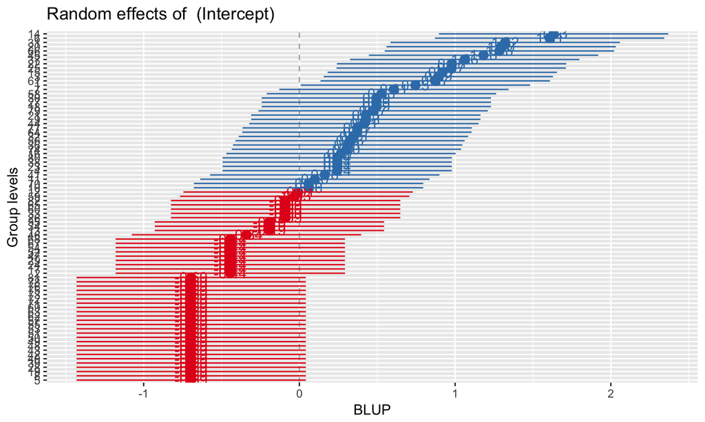

```r
library(sjPlot)
sjp.lmer(model.1, facet.grid = FALSE,
          sort = "sort.all")
```

```r
model.2 <- lmer(alcuse ~ time + (1 | id), data = alcohol1)
summary(model.2)
```

```
## Linear mixed model fit by REML ['lmerMod']
## Formula: alcuse ~ time + (1 | id)
##    Data: alcohol1
##
## REML criterion at convergence: 654.1
##
## Scaled residuals:
##      Min       1Q   Median       3Q      Max
## -2.19816 -0.66940  0.03001  0.44728  2.66167
##
## Random effects:
##  Groups   Name        Variance Std.Dev.
##  id       (Intercept) 0.5966   0.7724
##  Residual             0.4915   0.7011
## Number of obs: 246, groups:  id, 82
##
## Fixed effects:
##             Estimate Std. Error t value
## (Intercept)  0.65130    0.11077   5.880
## time         0.27065    0.05474   4.944
##
## Correlation of Fixed Effects:
##      (Intr)
## time -0.494
```

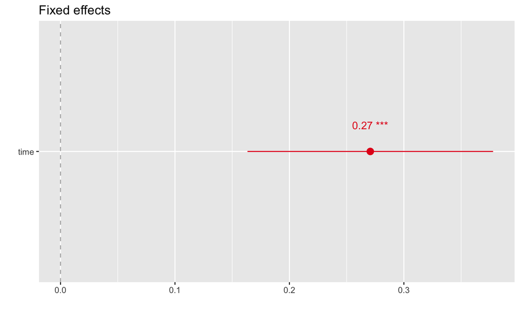

```r
sjp.lmer(model.2, type="fe")
```

```r
model.3 <- lmer(alcuse ~ time + (1 + time| id), data = alcohol1)
summary(model.3)

## Fixed effects are outside of the parenthesis
## and the random effects are inside
```

```
## Linear mixed model fit by REML ['lmerMod']
## Formula: alcuse ~ time + (1 + time | id)
##    Data: alcohol1
##
## REML criterion at convergence: 643.2
##
## Scaled residuals:
##      Min       1Q   Median       3Q      Max
## -2.48287 -0.37933 -0.07858  0.38876  2.49284
##
## Random effects:
##  Groups   Name        Variance Std.Dev. Corr
##  id       (Intercept) 0.6355   0.7972
##           time        0.1552   0.3939   -0.23
##  Residual             0.3373   0.5808
## Number of obs: 246, groups:  id, 82
##
## Fixed effects:
##             Estimate Std. Error t value
## (Intercept)  0.65130    0.10573   6.160
## time         0.27065    0.06284   4.307
##
## Correlation of Fixed Effects:
##      (Intr)
## time -0.441
```

```r
library(lmerTest)
summary(model.3)
#gives you p-values, if you really want it
```

```r
sjp.lmer(model.3)
```

```
## Plotting random effects...
```

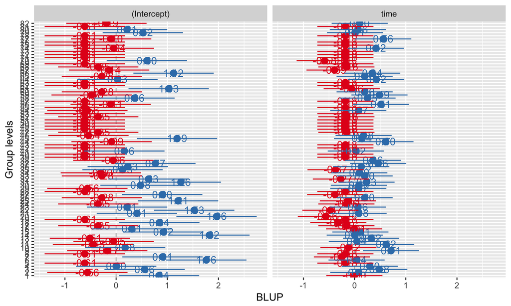

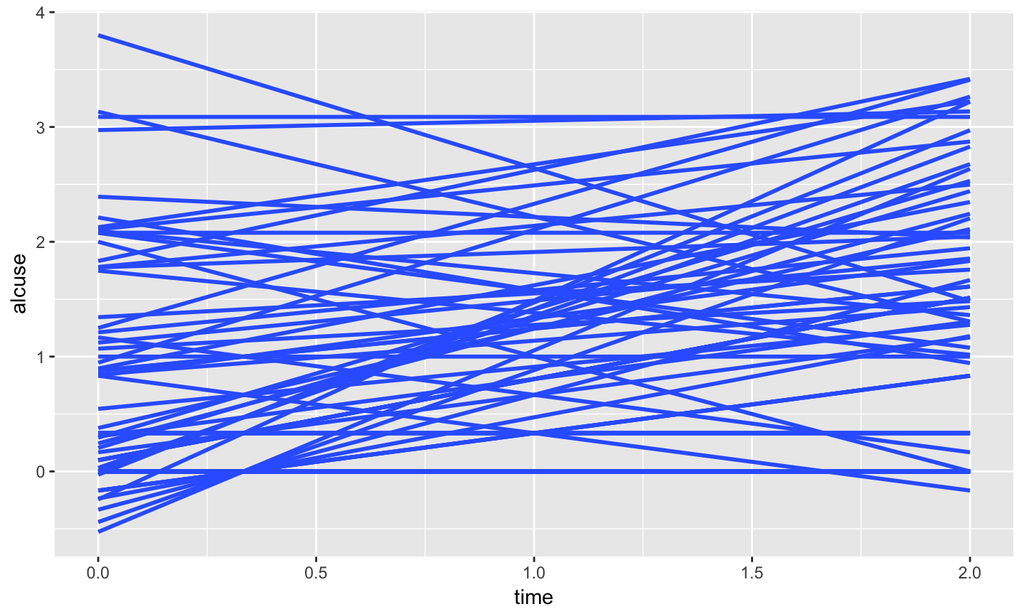

```r
ggplot(alcohol1,
   aes(x = time, y = alcuse, group = id)) + stat_smooth(method = "lm", se = FALSE)
```

```r
model.4 <- lmer(alcuse~ time + coa + coa*time + (time | id), data = alcohol1)
summary(model.4)
```

```
## Linear mixed model fit by REML ['lmerMod']
## Formula: alcuse ~ time + coa + coa * time + (time | id)
##    Data: alcohol1
##
## REML criterion at convergence: 631.9
##
## Scaled residuals:
##     Min      1Q  Median      3Q     Max
## -2.5522 -0.3827 -0.1063  0.3585  2.3708
##
## Random effects:
##  Groups   Name        Variance Std.Dev. Corr
##  id       (Intercept) 0.5068   0.7119
##           time        0.1586   0.3982   -0.23
##  Residual             0.3373   0.5808
## Number of obs: 246, groups:  id, 82
##
## Fixed effects:
##             Estimate Std. Error t value
## (Intercept)  0.31595    0.13232   2.388
## time         0.29296    0.08527   3.435
## coa          0.74321    0.19698   3.773
## time:coa    -0.04943    0.12695  -0.389
##
## Correlation of Fixed Effects:
##          (Intr) time   coa
## time     -0.460
## coa      -0.672  0.309
## time:coa  0.309 -0.672 -0.460
```

```r
tidy(model.4)
```

```
##                      term    estimate  std.error  statistic    group
## 1             (Intercept)  0.31595172 0.13231891  2.3878047    fixed
## 2                    time  0.29295517 0.08527403  3.4354557    fixed
## 3                     coa  0.74321203 0.19698266  3.7729821    fixed
## 4                time:coa -0.04942994 0.12694713 -0.3893742    fixed
## 5       sd_(Intercept).id  0.71189636         NA         NA       id
## 6              sd_time.id  0.39821932         NA         NA       id
## 7 cor_(Intercept).time.id -0.22943387         NA         NA       id
## 8 sd_Observation.Residual  0.58076865         NA         NA Residual
```

what does this look like for group effects?

```r
example
```

```
##     Subject  A Reaction
## 1       308 -1 249.5600
## 2       308 -1 258.7047
## 3       308 -1 250.8006
## 4       308 -1 321.4398
## 5       308 -1 356.8519
## 6       308  1 414.6901
## 7       308  1 382.2038
## 8       308  1 290.1486
## 9       308  1 430.5853
## 10      308  1 466.3535
## 11      309 -1 222.7339
## 12      309 -1 205.2658
## 13      309 -1 202.9778
## 14      309 -1 204.7070
```

[output cut: 166 more lines]

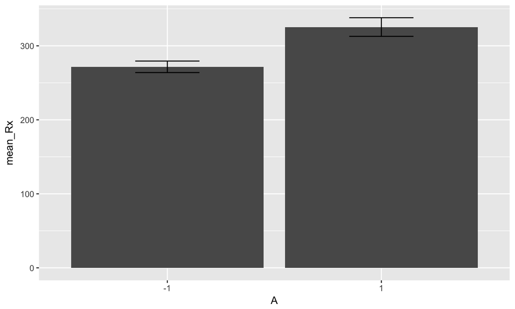

```r
ex.1 <- lmer(Reaction ~ 1 + (1|Subject), data = example)
summary(ex.1)
```

```
## Linear mixed model fit by REML ['lmerMod']
## Formula: Reaction ~ 1 + (1 | Subject)
##    Data: example
##
## REML criterion at convergence: 1904.3
##
## Scaled residuals:
##     Min      1Q  Median      3Q     Max
## -2.4983 -0.5501 -0.1476  0.5123  3.3446
##
## Random effects:
##  Groups   Name        Variance Std.Dev.
##  Subject  (Intercept) 1278     35.75
##  Residual             1959     44.26
## Number of obs: 180, groups:  Subject, 18
##
## Fixed effects:
##             Estimate Std. Error t value
## (Intercept)   298.51       9.05   32.98
```

```
## `sjp.lmer()` will become deprecated in the future. Please use `plot_model()` instead.
```

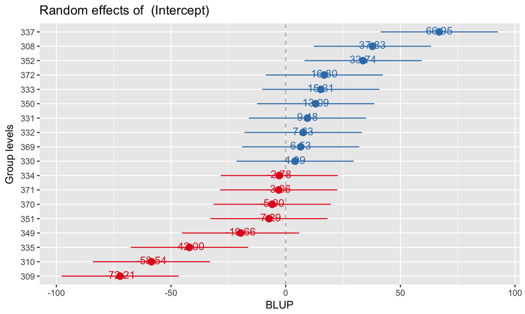

```r
library(sjPlot)
sjp.lmer(ex.1, facet.grid = FALSE,
          sort = "sort.all")
```

```r
reghelper::ICC(ex.1)
```

```
## [1] 0.3948896
```

```r
ex.2 <- lmer(Reaction ~ A + (1|Subject), data = example)
summary(ex.2)
```

```
## Linear mixed model fit by REML ['lmerMod']
## Formula: Reaction ~ A + (1 | Subject)
##    Data: example
##
## REML criterion at convergence: 1813.8
##
## Scaled residuals:
##     Min      1Q  Median      3Q     Max
## -2.5154 -0.6952  0.0217  0.6144  3.5380
##
## Random effects:
##  Groups   Name        Variance Std.Dev.
##  Subject  (Intercept) 1358     36.85
##  Residual             1163     34.11
## Number of obs: 180, groups:  Subject, 18
##
## Fixed effects:
##             Estimate Std. Error t value
## (Intercept)  271.630      9.400   28.90
## A1            53.755      5.085   10.57
##
## Correlation of Fixed Effects:
##    (Intr)
## A1 -0.270
```

how can you think of this graphically?

```r
ex.3 <- lmer(Reaction ~ A + (A|Subject), data = example)
summary(ex.3)
```

```
## Linear mixed model fit by REML ['lmerMod']
## Formula: Reaction ~ A + (A | Subject)
##    Data: example
##
## REML criterion at convergence: 1787.3
##
## Scaled residuals:
##     Min      1Q  Median      3Q     Max
## -3.3007 -0.5091 -0.0314  0.4551  3.8663
##
## Random effects:
##  Groups   Name        Variance Std.Dev. Corr
##  Subject  (Intercept) 749.1    27.37
##           A1          975.3    31.23    0.46
##  Residual             905.9    30.10
## Number of obs: 180, groups:  Subject, 18
##
## Fixed effects:
##             Estimate Std. Error t value
## (Intercept)  271.630      7.189  37.785
## A1            53.755      8.621   6.236
##
## Correlation of Fixed Effects:
##    (Intr)
## A1 0.188
```

```r
ranef(ex.3)
```

```
## $Subject
##     (Intercept)         A1
## 308  21.7017693  42.407727
## 309 -55.2429138 -44.640515
## 310 -45.8929881 -33.269807
## 330  11.6395169 -19.842088
## 331  16.6578842 -18.864320
## 332   4.6913134   7.716570
## 333  13.5915312   4.514793
## 334  -4.4328944   4.341514
## 335 -22.2291063 -51.989519
## 337  49.5023089  45.908933
## 349 -20.2346493   1.492818
## 350  -1.3749587  38.017575
## 351  -1.6480955 -14.837968
## 352  28.9500122  12.620995
## 369   5.2872776   3.261775
## 370 -15.1367314  24.262257
## 371   0.7332725  -9.958518
## 372  13.4374511   8.857780
```

```r
sjp.lmer(ex.3)
```

```
## Plotting random effects...
```

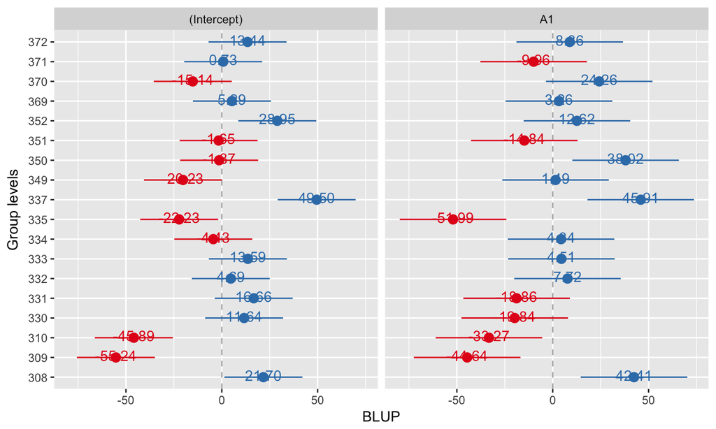

how can you think of this graphically?